# Homework4

Yeabin

2022-09-24

## Homework 4

```r
library(tidyverse)
library(ggthemes)
library(ggrepel)
```

We will use two data set county_map and county_data for this homework

### Part I

We merge the two data frames using the shared FIPS id column:

```
county_full <- left_join(county_map, county_data, by = "id")
```

Let’s draw two new county-level maps. Look at the column su_gun6. It is about firearm-related suicides per 100,000 population, 1999-2015. This type of data is called factor variable, cut into six categories. We also have a pop_dens6 variable that divides the population density into six categories.

#### Question 1

Draw a county-level map using su_gun6 variable. Make sure that you must use:

```
geom_polygon(size = 0.04)
coord_equal()
scale_fill_brewer(palette="Reds")
theme_map()
```

- What’s the role of 4 functions above?
- Improve the texts using labs(title = , fill = ) and theme(legend.position = )

#### Question 2

Draw a county-level map using pop_dens6 variable using the same functions above.

#### Question 3

What’s your interpretation regarding these two figures? (~ 200 words)

#### Question 4

Revisit *Flipped counties, 2016* figures in lecture 9.

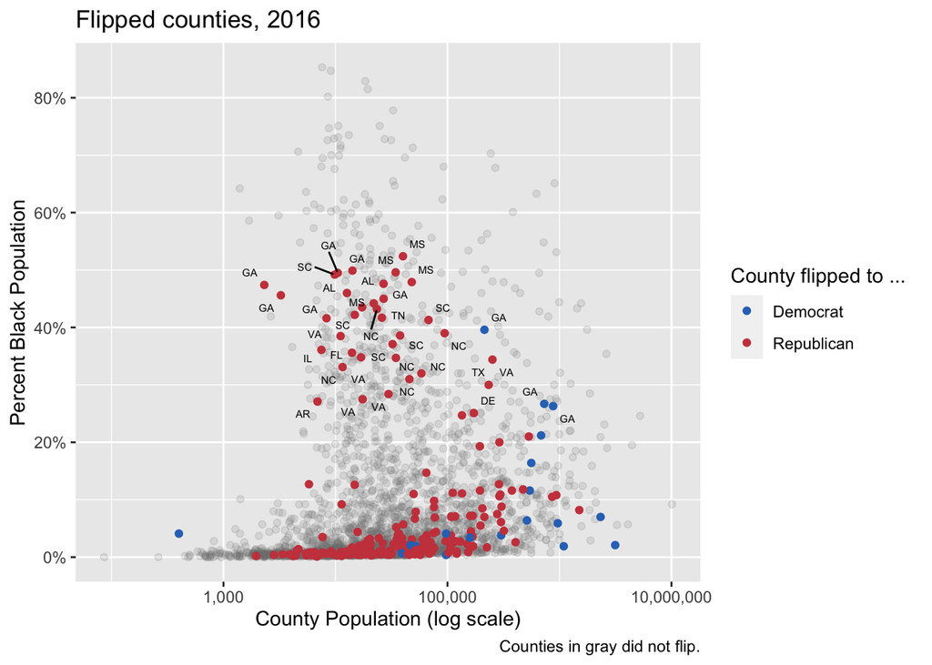

```r
setwd("~/Documents/ibs_course/BUS240/data")
load("county_data.rda")
party_colors <- c("#2E74C0", "#CB454A") # Democrat Blue and Republican Red
p0 <- ggplot(data = subset(county_data,
                           flipped == "No"),
             mapping = aes(x = pop,
                           y = black/100))
p1 <- p0 + geom_point(alpha = 0.15, color = "gray50") + scale_x_log10(labels=scales::comma)
p2 <- p1 + geom_point(data = subset(county_data,
                                    flipped == "Yes"),
                      mapping = aes(x = pop, y = black/100,
                                    color = partywinner16)) +
  scale_color_manual(values = party_colors)
p3 <- p2 + scale_y_continuous(labels=scales::percent) +
    labs(color = "County flipped to ... ",
         x = "County Population (log scale)",
         y = "Percent Black Population",
         title = "Flipped counties, 2016",
         caption = "Counties in gray did not flip.")
p4 <- p3 + geom_text_repel(data = subset(county_data,
                                      flipped == "Yes" &
                                      black  > 25),
                           mapping = aes(x = pop,
                                   y = black/100,
                                   label = state), size = 2)
p4
```

For this exercise,

1. create the scatter plot with the counties in which the number of population having less than 75 % of data points (the third quartile) only
2. use the partisan colors to show the counties flipped
3. plot the text labels for the counties flipped to Democrat
- the text label needs to address both county and state: suffolk county, MA